# Okhotsk Diatom Composition

## 5.1 Compare nMDS with species diversity

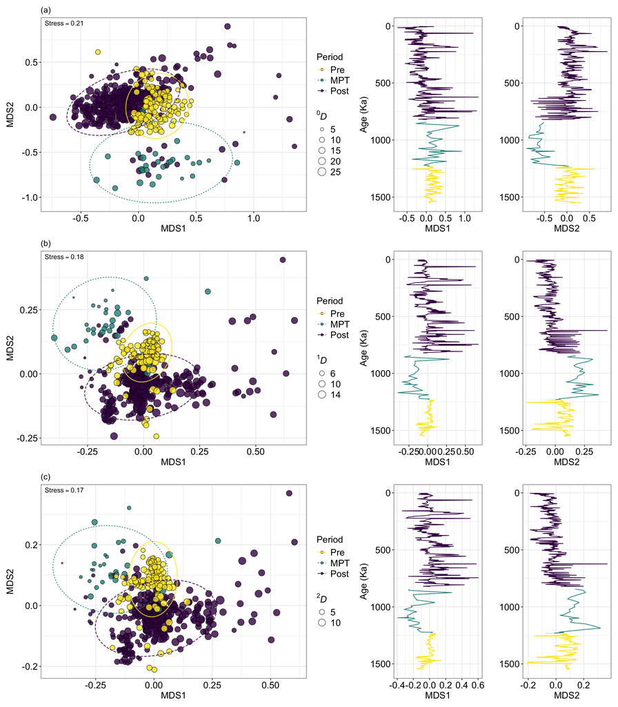

```r
lapply(mds, FUN=function(x){
  dat <- cbind(x$points, x$div)

  p1 <- ggplot()+
    geom_point(data=dat, aes(x=MDS1, y=MDS2, fill=Period2, size = qD), pch=21, alpha = 0.8)+
    stat_ellipse(data=dat, aes(x=MDS1, y=MDS2, linetype = Period2, colour=Period2), type="t")+
    annotate("text", x=-Inf, y=Inf, vjust=1.6, hjust=-0.1, label=paste("Stress", round(x$stress[1], 2), sep="=="), parse=T)+
    scale_fill_viridis_d(direction = -1)+
    scale_colour_viridis_d(direction = -1)+
    guides(fill = guide_legend(order=1), size = guide_legend(order=3), linetype = guide_legend(order=1), colour = guide_legend(order=1))+
    labs(x="MDS1", y="MDS2", fill="Period", size=x$qD.lab, linetype="Period", colour="Period", title = x$panel.lab)+
    theme_bw() %+replace% large

  p2 <- ggplot(dat, aes(x=Age_ka, y=MDS1))+
    #geom_point()+
    geom_path(aes(colour = Period2))+
    scale_colour_viridis_d(direction = -1)+
    labs(y="MDS1", x="Age (Ka)", colour="Period")+
    coord_flip()+
    scale_x_reverse()+
    theme_bw() %+replace% large %+replace% no_legend

  p3 <- ggplot(dat, aes(x=Age_ka, y=MDS2))+
    #geom_point()+
    geom_path(aes(colour = Period2))+
    scale_colour_viridis_d(direction = -1)+
    labs(y="MDS2", x="", colour="Period")+
    coord_flip()+
    scale_x_reverse()+
    theme_bw()%+replace% large %+replace% no_legend

  p1+p2+p3+plot_layout(width = c(3, 1, 1))

}) %>% wrap_plots(ncol=1)
```

Fig.X. nMDS overlaid with species diversity. Panels show nMDS based on (a) coverage-based Sørensen (q = 0), (b) Horn (q =1), and (c) Morisita-Horn dissimilarity (q = 2).

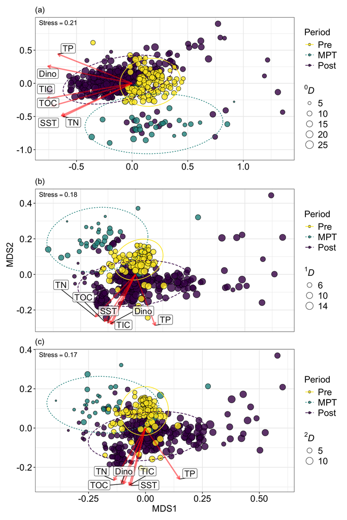

```r
mds[[1]]$sc <- 0.8
mds[[2]]$sc <- 0.3
mds[[3]]$sc <- 0.3

lapply(mds, FUN=function(x){
  dat <- cbind(x$points, x$div)
  lab <- data.frame(x$fit_concentration$vectors$arrows*x$sc)
  lab$label <- row.names(lab)
ggplot()+
    geom_point(data=dat, aes(x=MDS1, y=MDS2, fill=Period2, size = qD), pch=21, alpha = 0.8)+
    stat_ellipse(data=dat, aes(x=MDS1, y=MDS2, linetype = Period2, colour=Period2), type="t")+
    annotate("text", x=-Inf, y=Inf, vjust=1.6, hjust=-0.1, label=paste("Stress", round(x$stress[1], 2), sep="=="), parse=T)+
    geom_segment(data=lab, aes(x=0, y=0, xend=NMDS1, yend=NMDS2), size=1, arrow = arrow(length = unit(0.2,"cm")), colour=alpha("red", 0.5))+
    geom_label_repel(data=lab, aes(x=NMDS1, y=NMDS2, label=label), colour="gray10", fill=alpha("white", 0.7), size=5, label.padding = unit(0.2, "lines"))+
    scale_fill_viridis_d(direction = -1)+
    scale_colour_viridis_d(direction = -1)+
    guides(fill = guide_legend(order=1), size = guide_legend(order=3), linetype = guide_legend(order=1), colour = guide_legend(order=1))+
    labs(x="MDS1", y="MDS2", fill="Period", size=x$qD.lab, linetype="Period", colour="Period", title = x$panel.lab)+
    theme_bw() %+replace% large
}) %>% wrap_plots(ncol=1, axes = "collect")
```

Fig.X. nMDS overlaid with species diversity. Panels show nMDS based on (a) coverage-based Sørensen (q = 0), (b) Horn (q =1), and (c) Morisita-Horn dissimilarity (q = 2).

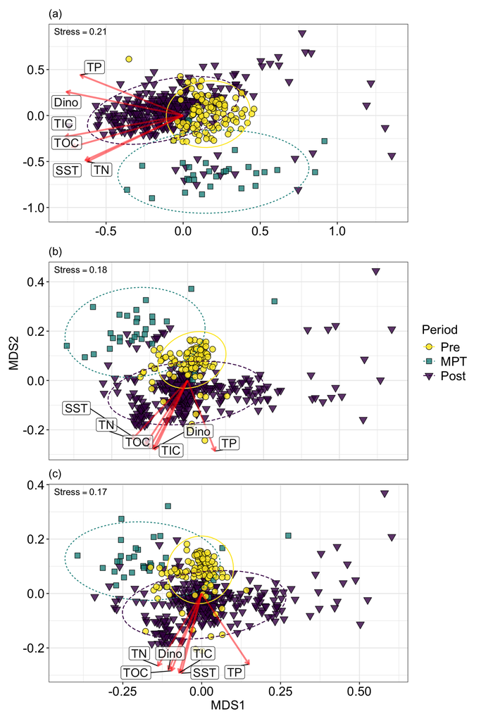

```r
mds[[1]]$sc <- 0.8
mds[[2]]$sc <- 0.3
mds[[3]]$sc <- 0.3

lapply(mds, FUN=function(x){
  dat <- cbind(x$points, x$div)
  lab <- data.frame(x$fit_concentration$vectors$arrows*x$sc)
  lab$label <- row.names(lab)
ggplot()+
    geom_point(data=dat, aes(x=MDS1, y=MDS2, fill=Period2, shape = Period2), alpha = 0.8, size = 3)+
    stat_ellipse(data=dat, aes(x=MDS1, y=MDS2, linetype = Period2, colour=Period2), type="t")+
    annotate("text", x=-Inf, y=Inf, vjust=1.6, hjust=-0.1, label=paste("Stress", round(x$stress[1], 2), sep="=="), parse=T)+
    geom_segment(data=lab, aes(x=0, y=0, xend=NMDS1, yend=NMDS2), size=1, arrow = arrow(length = unit(0.2,"cm")), colour=alpha("red", 0.5))+
    geom_label_repel(data=lab, aes(x=NMDS1, y=NMDS2, label=label), colour="gray10", fill=alpha("white", 0.7), size=5, label.padding = unit(0.2, "lines"))+
    scale_fill_viridis_d(direction = -1)+
    scale_colour_viridis_d(direction = -1)+
    scale_shape_manual(values = c(21, 22, 25))+
    labs(x="MDS1", y="MDS2", fill="Period", shape="Period", linetype="Period", colour="Period", title = x$panel.lab)+
    theme_bw() %+replace% large
}) %>% wrap_plots(ncol=1, axes = "collect", guides = "collect")
```

# 6 Distance-based redundent analysis (dbRDA)

```r
db <- lapply(sor1, FUN=function(x){
  out <- capscale(x ~ SST + TOC + TN + TP + TIC + Dino, data = div[!zero ,c("SST", "TOC", "TN", "TP", "TIC", "Dino")])
  fit <- as.data.frame(out$CCA$biplot)
  sc <- min(abs(c(range(out$CCA$u[,1]), range(out$CCA$u[,1]))))
  fit <- fit*sc
  fit$label <- row.names(fit)
  out$fit <- fit
  return(out)
})

# Combine mds object with alpha diversity data
db[[1]]$div <- cbind(div[!zero, 1:28], qD = div$d0[!zero])
db[[2]]$div <- cbind(div[!zero, 1:28], qD = div$d1[!zero], qE = div$e1[!zero])
db[[3]]$div <- cbind(div[!zero, 1:28], qD = div$d2[!zero], qE = div$e2[!zero])

db[[1]]$qD.lab <- expression(""^0*italic(D))
db[[2]]$qD.lab <- expression(""^1*italic(D))
db[[3]]$qD.lab <- expression(""^2*italic(D))

db[[1]]$panel.lab <- "(a)"
db[[2]]$panel.lab <- "(b)"
db[[3]]$panel.lab <- "(c)"
```

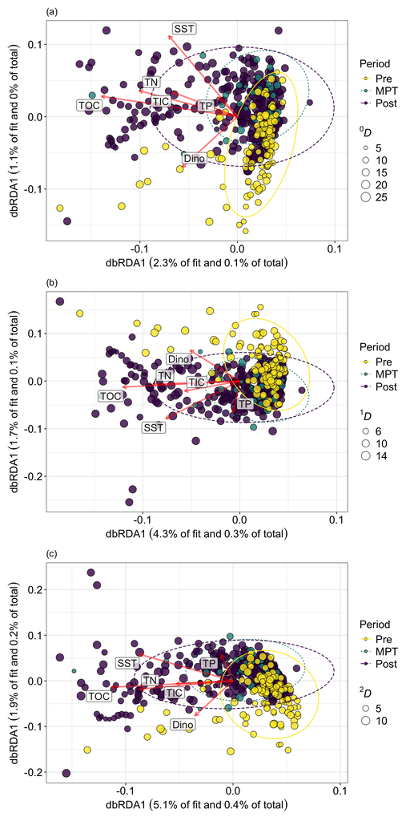

```r
lapply(db, FUN=function(x){
  dat <- cbind(x$CCA$u, x$div)
  lab <- data.frame(x$fit[,1:2]*2) # Environmental vectors
  lab$label <- row.names(lab)
  out <- summary(x)
  d1f <- round(out$cont$importance[2, 1]*100,1) # RDA1 variance explained of the fit
  d1t <- round(out$cont$importance[2, 1]*100*out$constr.chi/out$tot.chi, 1) # RDA1 variance explained of the total
  d2f <- round(out$cont$importance[2, 2]*100,1) # # RDA2 variance explained of the fit
  d2t <- round(out$cont$importance[2, 2]*100*out$constr.chi/out$tot.chi, 1) # # RDA1 variance explained of the total
ggplot()+
    geom_point(data=dat, aes(x=CAP1, y=CAP2, fill=Period2, size = qD), pch=21, alpha = 0.8)+
    stat_ellipse(data=dat, aes(x=CAP1, y=CAP2, linetype = Period2, colour=Period2), type="t")+
    geom_segment(data=lab, aes(x=0, y=0, xend=CAP1, yend=CAP2), size=1, arrow = arrow(length = unit(0.2,"cm")), colour=alpha("red", 0.5))+
    geom_label_repel(data=lab, aes(x=CAP1, y=CAP2, label=label), colour="gray10", fill=alpha("white", 0.7), size=5, label.padding = unit(0.2, "lines"))+
    scale_fill_viridis_d(direction = -1)+
    scale_colour_viridis_d(direction = -1)+
    guides(fill = guide_legend(order=1), size = guide_legend(order=3), linetype = guide_legend(order=1), colour = guide_legend(order=1))+
    labs(x=bquote("dbRDA1"~(.(d1f)*"% of fit and"~.(d1t)*"% of total")),
         y=bquote("dbRDA1"~(.(d2f)*"% of fit and"~.(d2t)*"% of total")),
         fill="Period", size=x$qD.lab, linetype="Period", colour="Period", title = x$panel.lab)+
    theme_bw() %+replace% large
}) %>% wrap_plots(ncol=1)
```

Fig.X. dbRDA overlaid with species diversity. Panels show dbRDA based on (a) coverage-based Sørensen (q = 0), (b) Horn (q =1), and (c) Morisita-Horn dissimilarity (q = 2).

# 7 Indicator Species Analysis (ISA)

The Indicator Value (IndVal), as defined by Dufrêne & Legendre (1997), represents a measure of species specificity and fidelity within a specified group, such as pre-MPT, MPT, post-MPT. Specifically, IndVal is calculated as square root of the product of relative abundance (i.e., specificity) and relative frequency (i.e., fidelity) of a species present in the defined group. The specificity measures how exclusive a species to a particular group and is equal to the mean species abundance in target group divided by the sum of mean species abundances across all groups. On the other hand, fidelity measures how often a species occurs within a group and is equal to the number of sites within the target group where species is present divided by the total number of sites in the target group.

The statistical significance of these IndVal values (or species-group associations) can be assessed through a permutation test (999 times) on the null hypothesis that the IndVal values in a specific group (or combination of groups) is not higher than the other groups.

## 7.1 Indicator species in each region

A total of 37 out of 51 species were identified as significant indicator species in the Pre, MPT, Post, and MPT+Post periods. Pre+MPT+Post period do not have p values, because no permutation test is conducted for species in the group encompassing all three periods.

```r
library(indicspecies)
# Indicator species
  IndVal <- multipatt(spp, sam$Period2, permutations=999)
  # Convert output to long format
  long <- cbind(Species=row.names(IndVal$A) %>% rep(each = 7),
                   # Specificity (= relative abundance)
                  pivot_longer(IndVal$A %>% as.data.frame, col=everything(), names_to = "index", values_to = "specificity"),
                  # Fidelity (= frequency of occurrence)
                  pivot_longer(IndVal$B %>% as.data.frame, col=everything(), names_to = "index", values_to = "fidelity")[,2],
                  # Indicator value (square root of A * B)
                  pivot_longer(IndVal$str %>% as.data.frame, col=everything(), names_to = "index", values_to = "stat")[,2]
                  )
# Add p values to the max indicator values among group (only those are consider indicator and tested)
long$p.value <- NA
long$index <- factor(long$index, levels=c("Pre", "MPT", "Post", "Pre+MPT", "MPT+Post", "Pre+Post", "Pre+MPT+Post"))
S <- IndVal$sign
S$index <- factor(S$index, levels=1:7, labels=c("Pre", "MPT", "Post", "Pre+MPT", "MPT+Post", "Pre+Post", "Pre+MPT+Post"))
keep <- match(paste(row.names(S), S$index), paste(long$Species, long$index))
long$p.value[keep] <- S$p.value
long <- lapply(group_split(long, index), FUN=function(x)x[order(-x$p.value, x$stat, decreasing = TRUE),]) %>% ldply
# Indicator species with p value
wp <- subset(long, stat!=0 & !is.na(p.value))
# Indicator species without p value
np <- subset(long, index == "Pre+MPT+Post" & is.na(p.value))
np <- subset(np, !np$Species %in% wp$Species)

# Combine significant and non-significant indicator species
all_species <- rbind(wp, np)
all_species$Group <- as.character(all_species$index)
all_species$Group[all_species$p.value >=0.05 | is.na(all_species$p.value)] <- "N.S."
all_species$Group <- factor(all_species$Group, levels = c("Pre", "MPT", "Post", "MPT+Post", "N.S."))
all_species$Label <- sub(" ", "~~", paste("italic(", sub(" *\\(.*| *\\var. egregius.*", "", all_species$Species), ")", sep=""))

ord <- order(all_species$Group, -all_species$stat)
all_species <- all_species[ord,]
all_species[,-8] %>% kable(caption = "Indicator species") %>% kable_classic()
```

Indicator species

|  | Species | index | specificity | fidelity | stat | p.value | Group |
| --- | --- | --- | --- | --- | --- | --- | --- |
| 1 | Asteromphalus brookei | Pre | 0.9448195 | 0.3928571 | 0.6092447 | 0.005 | Pre |
| 2 | Navicucula spp | Pre | 0.6812803 | 0.3839286 | 0.5114323 | 0.005 | Pre |
| 3 | Asteromphalus robustus | Pre | 1.0000000 | 0.0982143 | 0.3133916 | 0.005 | Pre |
| 52 | Actinocyclus oculatus | MPT | 0.9837721 | 0.1333333 | 0.3621735 | 0.005 | MPT |
| 53 | Thalassiosira jouseae | MPT | 0.8649865 | 0.1466667 | 0.3561807 | 0.005 | MPT |
| 54 | Shionodiscus spp | MPT | 0.8202696 | 0.1333333 | 0.3307103 | 0.005 | MPT |
| 55 | Coscinodiscus spp | MPT | 0.7811671 | 0.1200000 | 0.3061700 | 0.005 | MPT |
| 56 | Shionodiscus variantius | MPT | 0.7450176 | 0.0800000 | 0.2441340 | 0.005 | MPT |
| 57 | Actinoptychus spp. | MPT | 0.9029126 | 0.0266667 | 0.1551698 | 0.025 | MPT |
| 58 | Thalassiosira hyalina | MPT | 1.0000000 | 0.0200000 | 0.1414214 | 0.035 | MPT |
| 103 | Chaetoceros sp1 | Post | 0.9299845 | 0.8129032 | 0.8694754 | 0.005 | Post |
| 104 | Rhaphoneis surirella | Post | 0.9541502 | 0.4741935 | 0.6726454 | 0.005 | Post |
| 205 | Thalassiosira antarctica | MPT+Post | 0.8688234 | 0.6760870 | 0.7664204 | 0.005 | MPT+Post |
| 206 | Shionodiscus trifultus (Thalassiosira trifulta) | MPT+Post | 0.7303947 | 0.7130435 | 0.7216669 | 0.005 | MPT+Post |
| 207 | Thalassionema nitzschioides | MPT+Post | 0.7489185 | 0.5869565 | 0.6630103 | 0.005 | MPT+Post |
| 208 | Coscinodiscus marginatus | MPT+Post | 0.6594593 | 0.6152174 | 0.6369543 | 0.005 | MPT+Post |
| 209 | Proboscia curvirostris (Rhizosolenia styliformis) | MPT+Post | 0.5987432 | 0.6695652 | 0.6331648 | 0.005 | MPT+Post |
| 210 | Coscinodiscus oculus-iridis | MPT+Post | 0.7180213 | 0.5304348 | 0.6171414 | 0.005 | MPT+Post |
| 211 | Thalassiothrix longissima | MPT+Post | 0.5133927 | 0.6630435 | 0.5834395 | 0.005 | MPT+Post |
| 212 | Shionodiscus oestrupii (Thalassiosira decipiens) | MPT+Post | 0.4800808 | 0.7021739 | 0.5806033 | 0.005 | MPT+Post |
| 213 | Denticulopsis seminae (Neodenticula seminae) | MPT+Post | 0.4862682 | 0.6413043 | 0.5584317 | 0.005 | MPT+Post |
| 214 | Fragilariopsis oceanica (Nitzschia grunowii) | MPT+Post | 0.7637572 | 0.4021739 | 0.5542231 | 0.005 | MPT+Post |
| 215 | Actinocyclus ochotensis | MPT+Post | 0.4124351 | 0.6826087 | 0.5305957 | 0.005 | MPT+Post |
| 216 | Chaetoceros septentrionalis | MPT+Post | 0.8038044 | 0.3456522 | 0.5271022 | 0.005 | MPT+Post |
| 217 | Thalassiosira nordenskioeldii | MPT+Post | 0.7354681 | 0.3565217 | 0.5120648 | 0.005 | MPT+Post |
| 218 | Diploneis smithii | MPT+Post | 0.7056793 | 0.3413043 | 0.4907661 | 0.005 | MPT+Post |
| 219 | Porosira glacialis | MPT+Post | 0.4672672 | 0.4978261 | 0.4823047 | 0.005 | MPT+Post |
| 220 | Fragilariopsis cylindrus (Nitzschia cylindra) | MPT+Post | 0.6777354 | 0.3391304 | 0.4794170 | 0.005 | MPT+Post |
| 221 | Melosira sol | MPT+Post | 0.5632911 | 0.3630435 | 0.4522158 | 0.005 | MPT+Post |
| 222 | Pseudopodosira elegans | MPT+Post | 0.7317551 | 0.2717391 | 0.4459221 | 0.005 | MPT+Post |
| 223 | Thalassiosira lacustris | MPT+Post | 0.4928921 | 0.2826087 | 0.3732232 | 0.005 | MPT+Post |
| 224 | Coscinodiscus tabularis var. egregius | MPT+Post | 0.2442216 | 0.4021739 | 0.3134000 | 0.005 | MPT+Post |
| 225 | Delphineis kippae | MPT+Post | 0.7543582 | 0.0934783 | 0.2655487 | 0.005 | MPT+Post |
| 226 | Actinoptychus senarius | MPT+Post | 0.6191646 | 0.0630435 | 0.1975710 | 0.005 | MPT+Post |
| 227 | Cocconeis costata | MPT+Post | 0.4665821 | 0.0826087 | 0.1963256 | 0.005 | MPT+Post |
| 229 | Cocconeis spp | MPT+Post | 0.4790362 | 0.0695652 | 0.1825493 | 0.015 | MPT+Post |
| 228 | Eunotia spp | MPT+Post | 0.4200549 | 0.0500000 | 0.1449232 | 0.010 | MPT+Post |
| 307 | Rhizosolenia hebetata | Pre+MPT+Post | 1.0000000 | 0.7674825 | 0.8760608 | NA | N.S. |
| 311 | Actinocyclus curvatulus | Pre+MPT+Post | 1.0000000 | 0.7307692 | 0.8548504 | NA | N.S. |
| 318 | Paralia sulcata | Pre+MPT+Post | 1.0000000 | 0.5541958 | 0.7444433 | NA | N.S. |
| 325 | Bacterosira bathyomphala (Bacterosira fragilis) | Pre+MPT+Post | 1.0000000 | 0.3828671 | 0.6187626 | NA | N.S. |
| 59 | Actinocyclus spp. | MPT | 0.7798742 | 0.0333333 | 0.1612322 | 0.080 | N.S. |
| 60 | Detonula confervacea | MPT | 0.6739130 | 0.0266667 | 0.1340560 | 0.130 | N.S. |
| 61 | Asteromphalus spp. | MPT | 0.6739130 | 0.0266667 | 0.1340560 | 0.140 | N.S. |
| 105 | Cyclotella sp1 | Post | 1.0000000 | 0.0161290 | 0.1270001 | 0.170 | N.S. |
| 63 | Odontella sp. | MPT | 0.6739130 | 0.0200000 | 0.1160959 | 0.215 | N.S. |
| 62 | Stephanopyxis spp. | MPT | 0.9353448 | 0.0133333 | 0.1116748 | 0.190 | N.S. |
| 230 | Cybella spp | MPT+Post | 0.4027742 | 0.0260870 | 0.1025044 | 0.110 | N.S. |
| 106 | Actinoptychus vulgaris | Post | 1.0000000 | 0.0032258 | 0.0567962 | 1.000 | N.S. |
| 107 | Cerataulina bicomis | Post | 1.0000000 | 0.0032258 | 0.0567962 | 1.000 | N.S. |
| 231 | Nitzschia spp | MPT+Post | 0.3514644 | 0.0065217 | 0.0478765 | 0.430 | N.S. |

```r
# Top 3 indicator species from each group
top_species <- all_species %>% group_split(Group) %>% lapply(FUN=function(x)x[order(-x$stat),][1:3,]) %>% ldply %>% subset(!is.na(stat))
top_species[,-8] %>% kable(caption = "Only show the top three significant indicator species from each group. The Post period only have two significant indicator species. Three species with the highsest indicator values from Pre+MPT+Post are included. However, they are not significant indicator sepcies, because no permutation test was conducted") %>% kable_classic()
```

Only show the top three significant indicator species from each group. The Post period only have two significant indicator species. Three species with the highsest indicator values from Pre+MPT+Post are included. However, they are not significant indicator sepcies, because no permutation test was conducted

|  | Species | index | specificity | fidelity | stat | p.value | Group |
| --- | --- | --- | --- | --- | --- | --- | --- |
| 1 | Asteromphalus brookei | Pre | 0.9448195 | 0.3928571 | 0.6092447 | 0.005 | Pre |
| 2 | Navicucula spp | Pre | 0.6812803 | 0.3839286 | 0.5114323 | 0.005 | Pre |
| 3 | Asteromphalus robustus | Pre | 1.0000000 | 0.0982143 | 0.3133916 | 0.005 | Pre |
| 4 | Actinocyclus oculatus | MPT | 0.9837721 | 0.1333333 | 0.3621735 | 0.005 | MPT |
| 5 | Thalassiosira jouseae | MPT | 0.8649865 | 0.1466667 | 0.3561807 | 0.005 | MPT |
| 6 | Shionodiscus spp | MPT | 0.8202696 | 0.1333333 | 0.3307103 | 0.005 | MPT |
| 7 | Chaetoceros sp1 | Post | 0.9299845 | 0.8129032 | 0.8694754 | 0.005 | Post |
| 8 | Rhaphoneis surirella | Post | 0.9541502 | 0.4741935 | 0.6726454 | 0.005 | Post |
| 10 | Thalassiosira antarctica | MPT+Post | 0.8688234 | 0.6760870 | 0.7664204 | 0.005 | MPT+Post |
| 11 | Shionodiscus trifultus (Thalassiosira trifulta) | MPT+Post | 0.7303947 | 0.7130435 | 0.7216669 | 0.005 | MPT+Post |
| 12 | Thalassionema nitzschioides | MPT+Post | 0.7489185 | 0.5869565 | 0.6630103 | 0.005 | MPT+Post |
| 13 | Rhizosolenia hebetata | Pre+MPT+Post | 1.0000000 | 0.7674825 | 0.8760608 | NA | N.S. |
| 14 | Actinocyclus curvatulus | Pre+MPT+Post | 1.0000000 | 0.7307692 | 0.8548504 | NA | N.S. |
| 15 | Paralia sulcata | Pre+MPT+Post | 1.0000000 | 0.5541958 | 0.7444433 | NA | N.S. |

## 7.2 Cluster Analysis

Ward’s minimum variance method was applied to Sørensen dissimilarities (q = 0), Horn dissimilarities (q = 1), and Morisita-Horn dissimilarities (q = 2) among the samples. This method was also utilized for Hellinger distances between species. The heatmap illustrates the species count after applying a fourth root transformation. Due to the large number of columns representing species, the figures for the full species list are not shown. Heatmaps will be shown based on indicator species later.

```r
library(pheatmap)
library(RColorBrewer)

pheatmap2 <- function(mat, x, ...){

  # Hellinger distances between species
  dcols <- decostand(mat, "hellinger") %>% as.matrix %>%t %>% dist

  hc <- hclust(x, method="ward.D2")
  clust <- cutree(hc, k=4)

  # rearrange by latitude
  nc <- aggregate(sam$Age_ka[!zero], by=list(clust), FUN=max)[,2] %>% order(decreasing = TRUE)
  clust <- factor(clust, nc, 1:4)

  annotation_row <- data.frame(Period=sam$Period2[!zero], Cluster=clust)
  rownames(annotation_row) <- sam$Age_ka[!zero]
  annotation_colors <- list(
    Period = c("Pre"="#f3c300", "MPT"="#875692", "Post"="#f38400"),
    Cluster = c("1"="#a1caf1", "2"="#be0032", "3"="#c2b280", "4"="#848482"))

  pheatmap(mat^0.25,
         color = brewer.pal(9, "Blues"),
         clustering_distance_rows = x,
         clustering_distance_cols = dcols,
         clustering_method = "ward.D2",
         legend_breaks = 0:3,
         legend_labels = (0:3)^4,
         cutree_rows = 4,
         annotation_row = annotation_row,
         annotation_colors = annotation_colors,
         , ...)
}
```

### 7.2.1 Heatmap base on idicator species and Sørensen dissimilarities (q = 0)

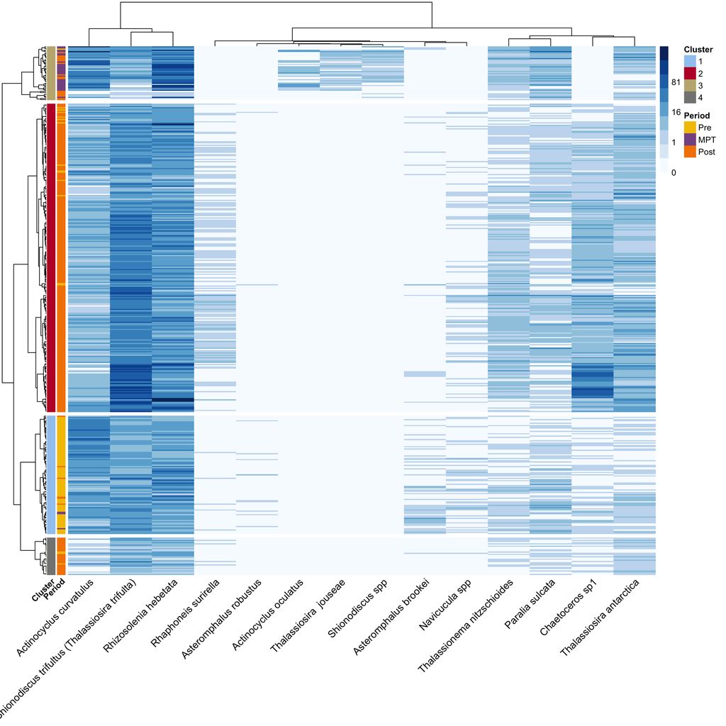

```r
pheatmap2(spp[!zero, top_species$Species], sor1[[1]], fontsize_col=12, show_rownames=FALSE, angle_col=45)
```

### 7.2.2 Heatmap base on idicator species and Horn dissimilarities (q = 1)

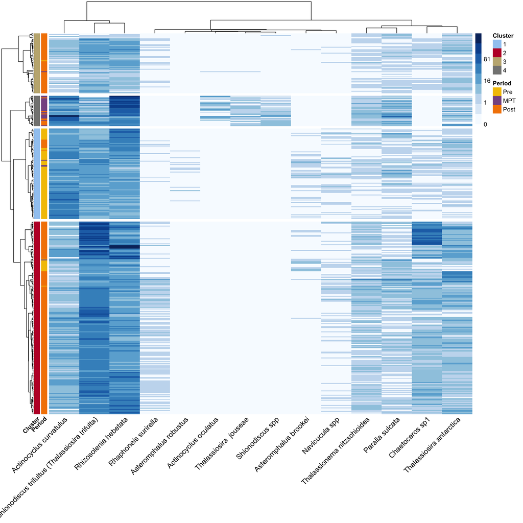

```r
pheatmap2(spp[!zero, top_species$Species], sor1[[2]], fontsize_col=12, show_rownames=FALSE, angle_col=45)
```

### 7.2.3 Heatmap base on idicator species and Morisita-Horn dissimilarities (q = 2)

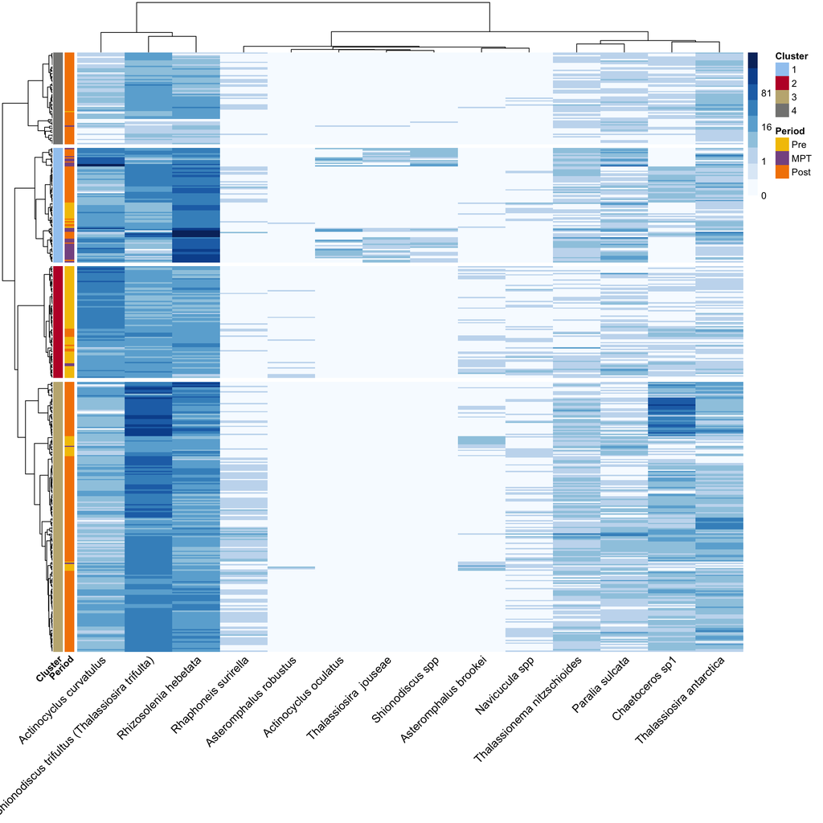

```r
pheatmap2(spp[!zero, top_species$Species], sor1[[3]], fontsize_col=12, show_rownames=FALSE, angle_col=45)
```